# Projet d’été : déterminant de l’arrêt lors d’une RI sur Internet

### Pouvoir ptrédictif des mesures métacognitives

```r
# Régression linéaire
model.meta_G <- lm(scale(Tps_Tot) ~ scale(FOFG) + Expertise + Complexite + Expertise*Complexite, test_heuristique.imp)

# Affichage du résumé du modèle
summary(model.meta_G)
```

```
##
## Call:
## lm(formula = scale(Tps_Tot) ~ scale(FOFG) + Expertise + Complexite +
##     Expertise * Complexite, data = test_heuristique.imp)
##
## Residuals:
##      Min       1Q   Median       3Q      Max
## -3.12206 -0.59190  0.01947  0.58067  3.10493
##
## Coefficients:
##                              Estimate Std. Error t value Pr(>|t|)
## (Intercept)                  -0.51366    0.07324  -7.013 4.91e-12 ***
## scale(FOFG)                   0.16608    0.03409   4.872 1.33e-06 ***
## Expertisenovice               0.10386    0.09920   1.047    0.295
## ComplexiteTI                  0.94779    0.10973   8.638  < 2e-16 ***
## ComplexiteTR                  0.83406    0.10730   7.773 2.32e-14 ***
## Expertisenovice:ComplexiteTI -0.27785    0.15038  -1.848    0.065 .
## Expertisenovice:ComplexiteTR -0.19524    0.15052  -1.297    0.195
## ---
## Signif. codes:  0 '***' 0.001 '**' 0.01 '*' 0.05 '.' 0.1 ' ' 1
##
## Residual standard error: 0.8908 on 812 degrees of freedom
## Multiple R-squared:  0.2123, Adjusted R-squared:  0.2064
## F-statistic: 36.47 on 6 and 812 DF,  p-value: < 2.2e-16
```

```r
# Tableau d'analyse de variance
anova(model.meta_G)
```

|  | Df | Sum Sq | Mean Sq | F value | Pr(>F) |
| --- | --- | --- | --- | --- | --- |
| scale(FOFG) | 1 | 61.897347 | 61.8973474 | 77.999018 | 6.279005e-18 |
| Expertise | 1 | 2.596629 | 2.5966292 | 3.272103 | 7.083696e-02 |
| Complexite | 2 | 106.166078 | 53.0830388 | 66.891799 | 1.283176e-27 |
| Expertise:Complexite | 2 | 2.964575 | 1.4822877 | 1.867883 | 1.551134e-01 |
| Residuals | 812 | 644.375370 | 0.7935657 | NA | NA |

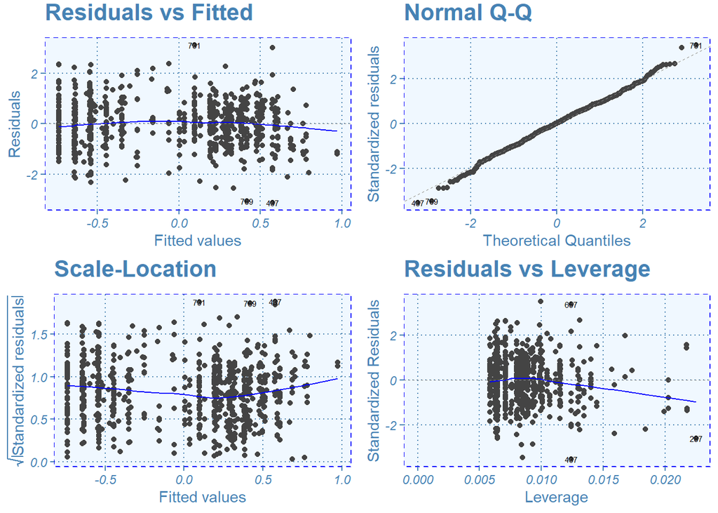

```r
library(ggfortify)

# Créer des graphiques de diagnostic
autoplot(model.meta_G, which = c(1:3,5), nrow = 2, ncol = 2, label.size = 2) +
  blue_theme()
```

```r
# Régression linéaire
model.meta_D <- lm(scale(Docs) ~ scale(FOFD) + Expertise + Complexite + Expertise*Complexite, test_heuristique.imp)

# Affichage du résumé du modèle
summary(model.meta_D)
```

```
##
## Call:
## lm(formula = scale(Docs) ~ scale(FOFD) + Expertise + Complexite +
##     Expertise * Complexite, data = test_heuristique.imp)
##
## Residuals:
##     Min      1Q  Median      3Q     Max
## -1.8050 -0.5692 -0.2113  0.4213  4.9547
##
## Coefficients:
##                              Estimate Std. Error t value Pr(>|t|)
## (Intercept)                  -0.32767    0.07710  -4.250 2.39e-05 ***
## scale(FOFD)                   0.22441    0.03633   6.177 1.03e-09 ***
## Expertisenovice               0.05566    0.10164   0.548  0.58408
## ComplexiteTI                  0.76571    0.11584   6.610 6.95e-11 ***
## ComplexiteTR                  0.38245    0.11253   3.399  0.00071 ***
## Expertisenovice:ComplexiteTI -0.24864    0.15410  -1.614  0.10702
## Expertisenovice:ComplexiteTR -0.04022    0.15384  -0.261  0.79383
## ---
## Signif. codes:  0 '***' 0.001 '**' 0.01 '*' 0.05 '.' 0.1 ' ' 1
##
## Residual standard error: 0.9112 on 812 degrees of freedom
## Multiple R-squared:  0.1758, Adjusted R-squared:  0.1697
## F-statistic: 28.87 on 6 and 812 DF,  p-value: < 2.2e-16
```

```r
# Tableau d'analyse de variance
anova(model.meta_D)
```

|  | Df | Sum Sq | Mean Sq | F value | Pr(>F) |
| --- | --- | --- | --- | --- | --- |
| scale(FOFD) | 1 | 92.137948 | 92.1379477 | 110.972704 | 2.071412e-24 |
| Expertise | 1 | 1.564639 | 1.5646395 | 1.884482 | 1.702047e-01 |
| Complexite | 2 | 47.773217 | 23.8866085 | 28.769488 | 8.479931e-13 |
| Expertise:Complexite | 2 | 2.340267 | 1.1701335 | 1.409331 | 2.449036e-01 |
| Residuals | 812 | 674.183929 | 0.8302758 | NA | NA |

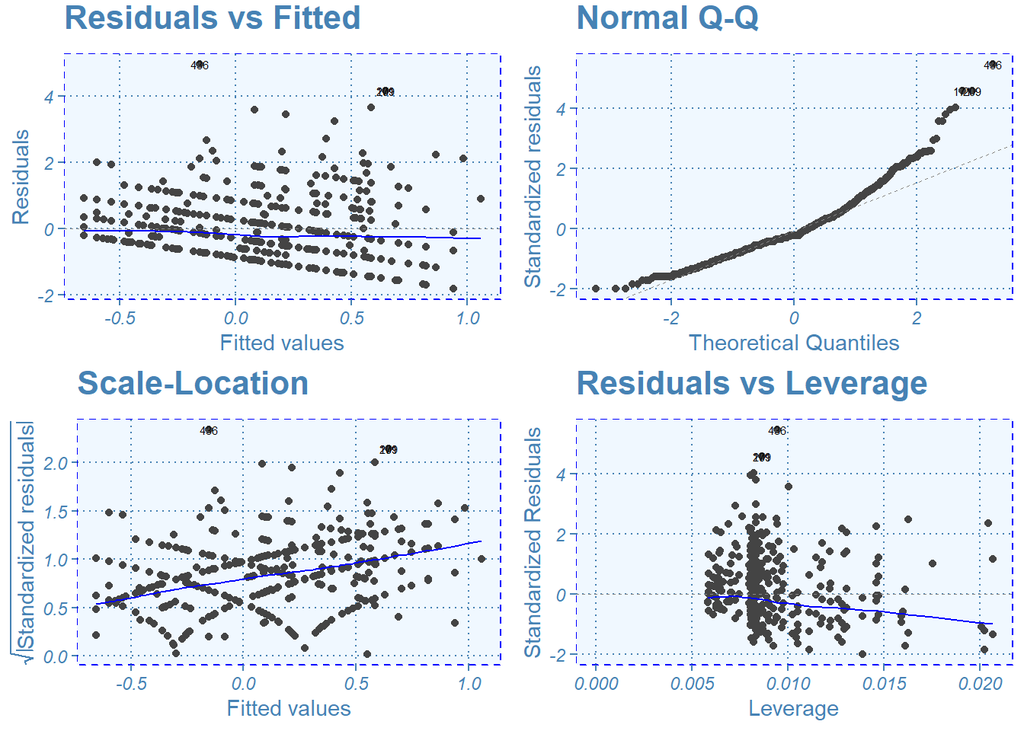

```r
library(ggfortify)

# Créer des graphiques de diagnostic
autoplot(model.meta_D, which = c(1:3,5), nrow = 2, ncol = 2, label.size = 2) +
  blue_theme()
```

Comme envisagé, les mesures métacognitives du FOFD et du FOFG montrent un effet sur le temps d’arrêt et le nombre de documents, et permettent de prédire le temps total (FOFG) ainsi que le nombre de documents (FOFD).

## Approfondissement : relations entre facteurs experimentaux et variables d’intérêts

### Expertise vs c.Docs

```r
# Mozaic plot sur contingence et residus du test chi2
contingency_table <- with(test_heuristique.imp, table(Expertise, c.Docs))
contingency_df <- test_heuristique.imp[,c("Expertise", "c.Docs")]

# Effectuer un test du chi carré
chi2_test <- chisq.test(contingency_table)

# Afficher les résultats du test et les fréquences attendues
print("Résultats du test du chi carré :")
```

```
## [1] "Résultats du test du chi carré :"
```

```r
print(chi2_test)
```

```
##
##  Pearson's Chi-squared test
##
## data:  contingency_table
## X-squared = 1.5996, df = 3, p-value = 0.6595
```

```r
print("Fréquences attendues :")
```

```
## [1] "Fréquences attendues :"
```

```r
print(chi2_test$expected)
```

```
##          c.Docs
## Expertise    (0,1]    (1,2]    (2,3] (3,Inf]
##    expert 143.9707 101.6264 61.77289  100.63
##    novice 145.0293 102.3736 62.22711  101.37
```

```r
library(vcd)
library(lsr)

# afficher le V de cramer
V <- cramersV(contingency_table)
cat(paste("V de Cramer: V =", round(V, 2)), "\n")
```

```
## V de Cramer: V = 0.04
```

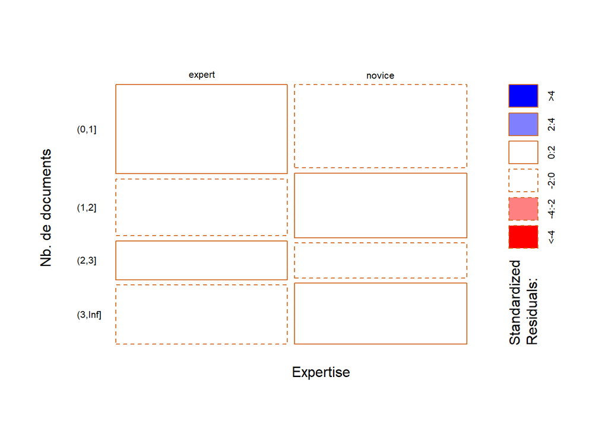

```r
# Créer un graphique en mosaïque pour les résidus du test du chi carré
mosaicplot(contingency_table, main = NULL,
           xlab = "Expertise",
           ylab = "Nb. de documents",
           las = 1,
           border = "chocolate",
           shade=TRUE,
           )
```

### Complexité vs c.Docs

```r
# Mozaic plot sur contingence et residus du test chi2
contingency_table <- with(test_heuristique.imp, table(Complexite, c.Docs))
contingency_df <- test_heuristique.imp[,c("Complexite", "c.Docs")]

# Effectuer un test du chi carré
chi2_test <- chisq.test(contingency_table)

# Afficher les résultats du test et les fréquences attendues
print("Résultats du test du chi carré :")
```

```
## [1] "Résultats du test du chi carré :"
```

```r
print(chi2_test)
```

```
##
##  Pearson's Chi-squared test
##
## data:  contingency_table
## X-squared = 129.49, df = 6, p-value < 2.2e-16
```

```r
print("Fréquences attendues :")
```

```
## [1] "Fréquences attendues :"
```

```r
print(chi2_test$expected)
```

```
##           c.Docs
## Complexite     (0,1]    (1,2]    (2,3]  (3,Inf]
##         TC 116.79976 82.44689 50.11477 81.63858
##         TI  86.10012 60.77656 36.94261 60.18071
##         TR  86.10012 60.77656 36.94261 60.18071
```

```r
library(vcd)
library(lsr)

# afficher le V de cramer
V <- cramersV(contingency_table)
cat(paste("V de Cramer: V =", round(V, 2)), "\n")
```

```
## V de Cramer: V = 0.28
```

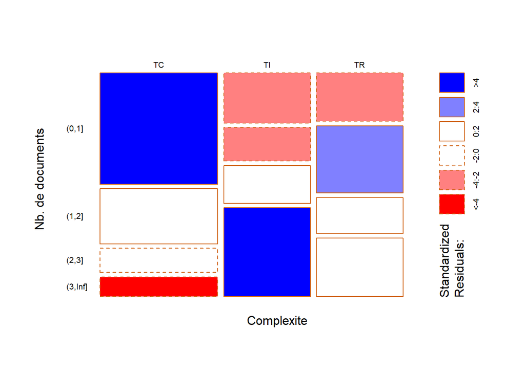

```r
# Créer un graphique en mosaïque pour les résidus du test du chi carré
mosaicplot(contingency_table, main = NULL,
           xlab = "Complexite",
           ylab = "Nb. de documents",
           las = 1,
           border = "chocolate",
           shade=TRUE,
           )
```

L’analyse complémentaire montre que le nombre de documents est sensible au niveau de complexité, avec un Chi2 significatif et un V de cramer de 0,28, mais pas à l’expertise.

### TG_Tot vs Expertise, Complexite et Interaction Expertise*Complexite

```r
# ANOVA
model.TG <- aov(TG_Tot ~ Expertise + Complexite + Expertise*Complexite, test_heuristique.imp)

# Affichage du résumé du modèle ANOVA
summary(model.TG)
```

```
##                       Df Sum Sq Mean Sq F value Pr(>F)
## Expertise              1 0.0174 0.01740   4.765 0.0293 *
## Complexite             2 0.2841 0.14207  38.892 <2e-16 ***
## Expertise:Complexite   2 0.0317 0.01584   4.337 0.0134 *
## Residuals            813 2.9698 0.00365
## ---
## Signif. codes:  0 '***' 0.001 '**' 0.01 '*' 0.05 '.' 0.1 ' ' 1
```

```r
# ANOVA
library(rstatix)
model.TG2 <- test_heuristique.imp %>% anova_test(TG_Tot ~ Expertise + Complexite + Expertise*Complexite)
model.TG2
```

|  | Effect | DFn | DFd | F | p | p<.05 | ges |
| --- | --- | --- | --- | --- | --- | --- | --- |
| 1 | Expertise | 1 | 813 | 5.733 | 1.7e-02 | * | 0.007 |
| 2 | Complexite | 2 | 813 | 38.892 | 7.4e-17 | * | 0.087 |
| 3 | Expertise:Complexite | 2 | 813 | 4.337 | 1.3e-02 | * | 0.011 |

```r
# Affichage du résumé du modèle ANOVA
summary(model.TG2)
```

```
##     Effect               DFn             DFd            F
##  Length:3           Min.   :1.000   Min.   :813   Min.   : 4.337
##  Class :character   1st Qu.:1.500   1st Qu.:813   1st Qu.: 5.035
##  Mode  :character   Median :2.000   Median :813   Median : 5.733
##                     Mean   :1.667   Mean   :813   Mean   :16.321
##                     3rd Qu.:2.000   3rd Qu.:813   3rd Qu.:22.312
##                     Max.   :2.000   Max.   :813   Max.   :38.892
##        p             p<.05                ges
##  Min.   :0.0000   Length:3           Min.   :0.007
##  1st Qu.:0.0065   Class :character   1st Qu.:0.009
##  Median :0.0130   Mode  :character   Median :0.011
##  Mean   :0.0100                      Mean   :0.035
##  3rd Qu.:0.0150                      3rd Qu.:0.049
##  Max.   :0.0170                      Max.   :0.087
```

Les variables de l’expertise et de la complexité montrent un effet principal sur le taux de gain, comme envisagé par les hypothèses. Les analyse ont également souligné la présence d’une interaction entre expertise et complexité.

```r
# Test post-hoc
TukeyHSD(model.TG, "Complexite")
```

```
##   Tukey multiple comparisons of means
##     95% family-wise confidence level
##
## Fit: aov(formula = TG_Tot ~ Expertise + Complexite + Expertise * Complexite, data = test_heuristique.imp)
##
## $Complexite
##               diff          lwr         upr    p adj
## TI-TC -0.041185140 -0.053159228 -0.02921105 0.000000
## TR-TC -0.033813627 -0.045787715 -0.02183954 0.000000
## TR-TI  0.007371513 -0.005476546  0.02021957 0.369501
```

```r
TukeyHSD(model.TG, "Expertise:Complexite")
```

```
##   Tukey multiple comparisons of means
##     95% family-wise confidence level
##
## Fit: aov(formula = TG_Tot ~ Expertise + Complexite + Expertise * Complexite, data = test_heuristique.imp)
##
## $`Expertise:Complexite`
##                             diff         lwr          upr     p adj
## novice:TC-expert:TC -0.024561914 -0.04355135 -0.005572483 0.0032003
## expert:TI-expert:TC -0.051150241 -0.07180615 -0.030494331 0.0000000
## novice:TI-expert:TC -0.056223841 -0.07707280 -0.035374880 0.0000000
## expert:TR-expert:TC -0.048447603 -0.06910351 -0.027791692 0.0000000
## novice:TR-expert:TC -0.044027824 -0.06487678 -0.023178863 0.0000000
## expert:TI-novice:TC -0.026588327 -0.04695209 -0.006224560 0.0028070
## novice:TI-novice:TC -0.031661926 -0.05222149 -0.011102366 0.0001785
## expert:TR-novice:TC -0.023885689 -0.04424946 -0.003521922 0.0108832
## novice:TR-novice:TC -0.019465910 -0.04002547  0.001093650 0.0753960
## novice:TI-expert:TI -0.005073599 -0.02718160  0.017034400 0.9865569
## expert:TR-expert:TI  0.002702638 -0.01922340  0.024628676 0.9992895
## novice:TR-expert:TI  0.007122417 -0.01498558  0.029230417 0.9413343
## expert:TR-novice:TI  0.007776238 -0.01433176  0.029884238 0.9163979
## novice:TR-novice:TI  0.012196017 -0.01009246  0.034484493 0.6232398
## novice:TR-expert:TR  0.004419779 -0.01768822  0.026527779 0.9928649
```

```r
TukeyHSD(model.TG, "Expertise")
```

```
##   Tukey multiple comparisons of means
##     95% family-wise confidence level
##
## Fit: aov(formula = TG_Tot ~ Expertise + Complexite + Expertise * Complexite, data = test_heuristique.imp)
##
## $Expertise
##                       diff         lwr           upr     p adj
## novice-expert -0.009219817 -0.01751076 -0.0009288757 0.0293361
```

L’analyse des test post-hoc confirme les effets des variables Expertise et Complexité sur le taux de gain. Le test de Tukey souligne toutefois que les interactions existent entre ces deux facteurs pour les tâches uniquement pour les tâches sans complexité TC. La complexité en tant que telle impacte bien le taux de gain, mais de manière identique entre les novices et les experts (sans différences significatives) pour les tâches TR et TI (par rapport aux tâches TC). Si globalement les experts et les novices se distinguent, il semble que ce ne soit que sur les niveaux d’incertitude les plus faibles (Tc). L’expertise ne semble pas avoir apporter de ressources cognitives suffisantes pour compenser l’augmentation de la complexité, invalidant notre hypothèse.